# Machine Learning R

Cristopher Valenzuela

3 de marzo de 2022

# Arboles de clasificación.

```r
#Cargamos los datos

cancer<-read.csv("C:\\Users\\Cristopher\\Desktop\\datos omicos git\\Machine learning R\\machine_learning_R\\BreastCancer1.csv", stringsAsFactors = TRUE)


str(cancer)
```

```
## 'data.frame':    569 obs. of  32 variables:
##  $ id                     : int  842302 842517 84300903 84348301 84358402 843786 844359 84458202 844981 84501001 ...
##  $ radius_mean            : num  18 20.6 19.7 11.4 20.3 ...
##  $ texture_mean           : num  10.4 17.8 21.2 20.4 14.3 ...
##  $ perimeter_mean         : num  122.8 132.9 130 77.6 135.1 ...
##  $ area_mean              : num  1001 1326 1203 386 1297 ...
##  $ smoothness_mean        : num  0.1184 0.0847 0.1096 0.1425 0.1003 ...
##  $ compactness_mean       : num  0.2776 0.0786 0.1599 0.2839 0.1328 ...
##  $ concavity_mean         : num  0.3001 0.0869 0.1974 0.2414 0.198 ...
##  $ concave.points_mean    : num  0.1471 0.0702 0.1279 0.1052 0.1043 ...
##  $ symmetry_mean          : num  0.242 0.181 0.207 0.26 0.181 ...
##  $ fractal_dimension_mean : num  0.0787 0.0567 0.06 0.0974 0.0588 ...
##  $ radius_se              : num  1.095 0.543 0.746 0.496 0.757 ...
##  $ texture_se             : num  0.905 0.734 0.787 1.156 0.781 ...
##  $ perimeter_se           : num  8.59 3.4 4.58 3.44 5.44 ...
```

[output cut: 18 more lines]

```r
library(caret)
```

```r
library(rpart) #construccion de arboles
library(rpart.plot) #graficar dichos arboles
library(tidyverse)
library(lattice)
library(randomForest)
#primero eliminamos los id porque es informaicon redundante

cancer = cancer[,-1]

#creamos la particion del datasets

trainings.ids<-createDataPartition(cancer$diagnosis,p=0.7,list = FALSE)

#generamos el arbol
#establecemos las variables dependientes y las independientes

mod <- randomForest(x = cancer[trainings.ids , 1:30],
                    y = cancer[trainings.ids , 31],
                    ntree = 100,
                    keep.forest = TRUE)

mod
```

```
##
## Call:
##  randomForest(x = cancer[trainings.ids, 1:30], y = cancer[trainings.ids,      31], ntree = 100, keep.forest = TRUE)
##                Type of random forest: classification
##                      Number of trees: 100
## No. of variables tried at each split: 5
##
##         OOB estimate of  error rate: 4.01%
## Confusion matrix:
##     B   M class.error
## B 245   5   0.0200000
## M  11 138   0.0738255
```

```r
#vemos que tan bueno es el modelo

pred<-predict(mod,cancer[-trainings.ids,])
table(cancer[-trainings.ids,"diagnosis"],pred,dnn= c("Actual","Predicho"))
```

```
##       Predicho
## Actual   B   M
##      B 105   2
##      M   7  56
```

Creamos curva ROC

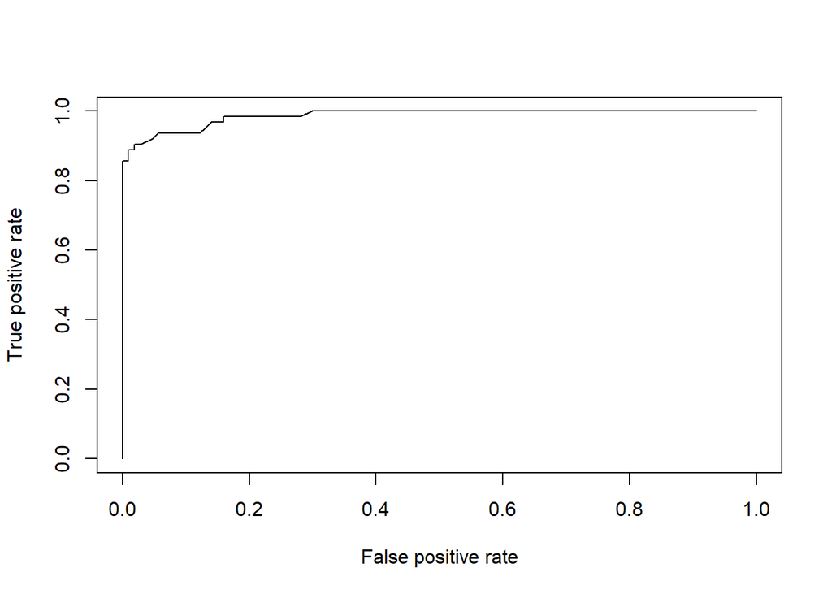

```r
library(ROCR)
probs<-predict(mod,cancer[-trainings.ids,], type = "prob")
pred<-prediction(probs[,2],cancer[-trainings.ids,"diagnosis"])
perf<-performance(pred,"tpr","fpr")
plot(perf)
```

La clasificacion es muy buena.

# Maquinas de soporte vectorial.

```r
#Se utilizaran los mismos datos del ejercicio anterior

cancer<-read.csv("C:\\Users\\Cristopher\\Desktop\\datos omicos git\\Machine learning R\\machine_learning_R\\BreastCancer1.csv", stringsAsFactors = TRUE)

cancer = cancer[,-1]

library(caret)
library(e1071)

#Como ya tenemos los datos como dataframe y la variable dependiente convertida en factor, asi que procedemos a la
#particion de datos en 80 y 20.

t.ids2<- createDataPartition(cancer$diagnosis, p = 0.7, list = F)

#creamos el modelo
mod <- svm(diagnosis ~ ., data = cancer[t.ids2,])

mod
```

```
##
## Call:
## svm(formula = diagnosis ~ ., data = cancer[t.ids2, ])
##
##
## Parameters:
##    SVM-Type:  C-classification
##  SVM-Kernel:  radial
##        cost:  1
##
## Number of Support Vectors:  100
```

Veremos que tan bien predice

```r
table(cancer[t.ids2,"diagnosis"], fitted(mod), dnn = c("Actual","Predicho"))
```

```
##       Predicho
## Actual   B   M
##      B 250   0
##      M   4 145
```

Obtenemos una clasificacion muy buena en este caso.

Intentaremos predecir en base al modelo anterior, los dato que no tomamos en la creacion del modelo anterior.

```r
pred<- predict(mod, cancer[-t.ids2,])
table(cancer[-t.ids2,"diagnosis"],pred,dnn = c("Actual","Predicho"))
```

```
##       Predicho
## Actual   B   M
##      B 105   2
##      M   3  60
```

Graficamos la division

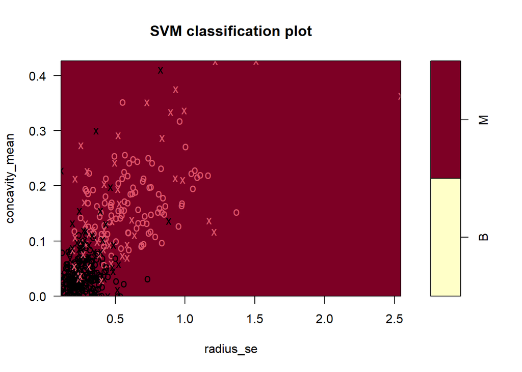

```r
plot(mod , data = cancer[t.ids2,], concavity_mean ~ radius_se)
```

Sin separacion de rectas

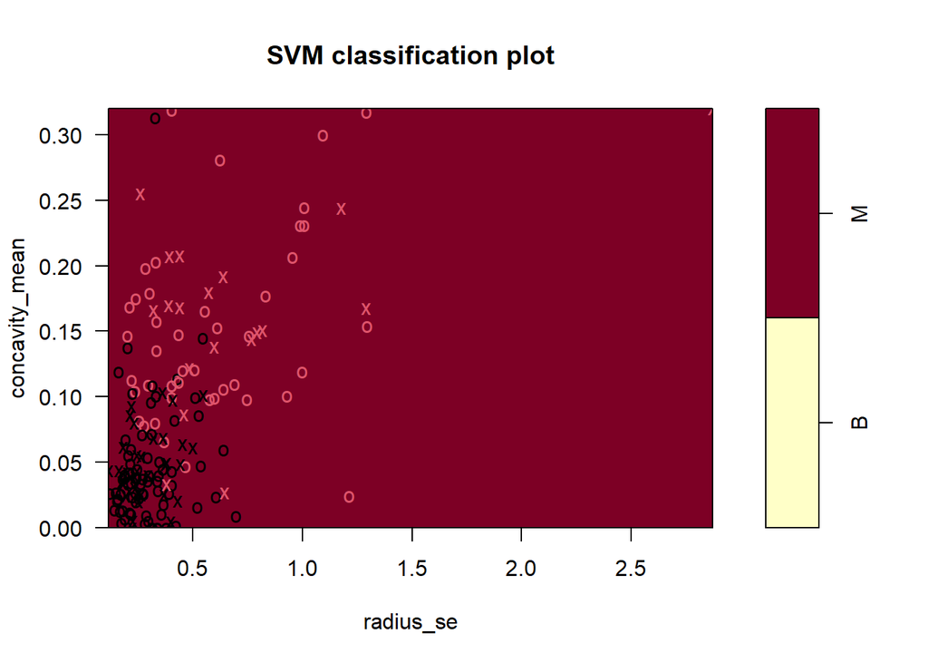

```r
plot(mod , data = cancer[-t.ids2,], concavity_mean ~ radius_se)
```

Tambien podriamos agregarles pesos a las clases, por ejemplo al M = 0.3 y al B=0.7

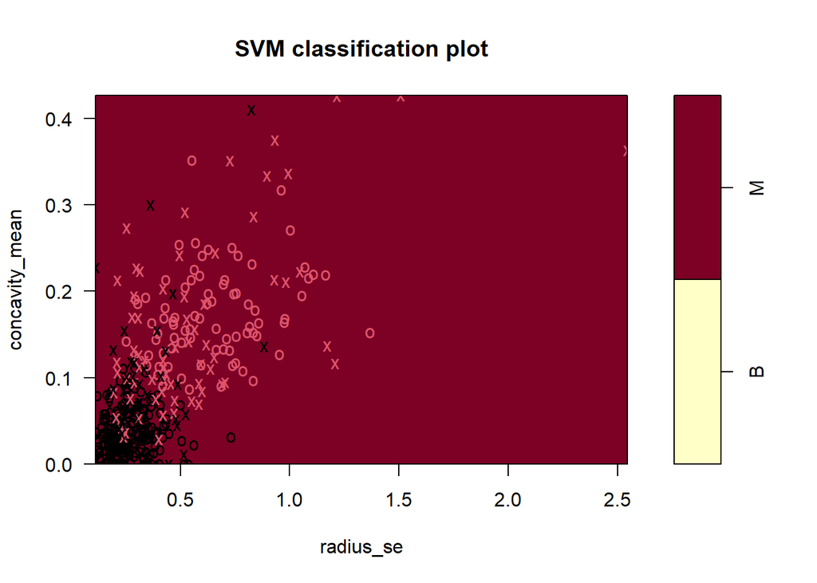

```r
mod <- svm(diagnosis ~ ., data = cancer[t.ids2, ], class.weights=c("M"=0.3, "B"=0.7))
plot(mod , data = cancer[t.ids2,], concavity_mean ~ radius_se)
```

# Naive Bayes.

```r
library(e1071)
library(caret)
library(naivebayes)
library(readr)

#utilizamos datos de "churn" y la variable dependiente sera la variable "churn"

datos_churn<- read.csv("C:\\Users\\Cristopher\\Desktop\\datos omicos git\\Machine learning R\\machine_learning_R\\Archivo data - 2022.csv", stringsAsFactors = TRUE)

datos_churn<- datos_churn %>%
  select(gender,PhoneService,OnlineSecurity,OnlineBackup,PaperlessBilling,Churn)


datos_churn$OnlineSecurity <- gsub('No internet service', 'No', datos_churn$OnlineSecurity)
datos_churn$OnlineBackup <- gsub('No internet service', 'No',datos_churn$OnlineBackup)

datos_churn$PhoneService <- factor(datos_churn$PhoneService,
                                   levels = c("Yes","No"),
                                   labels = c("1","0"))

datos_churn$OnlineSecurity<-factor(datos_churn$OnlineSecurity,
                                   levels = c("Yes","No"),
                                   labels = c("1","0"))

datos_churn$OnlineBackup<-factor(datos_churn$OnlineBackup,
                                   levels = c("Yes","No"),
                                   labels = c("1","0"))


datos_churn$OnlineSecurity<-factor(datos_churn$OnlineSecurity,
                                   levels = c("Yes","No"),
                                   labels = c("1","0"))

datos_churn$PaperlessBilling<-factor(datos_churn$PaperlessBilling,
                                   levels = c("Yes","No"),
                                   labels = c("1","0"))


datos_churn$Churn<-factor(datos_churn$Churn,
                          levels = c("Yes","No"),
                          labels = c("1","0"))
datos_churn$gender<-factor(datos_churn$gender,
                           levels = c("Male","Female"),
                           labels = c("1","0"))

write.csv(datos_churn,"C:\\Users\\Cristopher\\Desktop\\datos omicos git\\Machine learning R\\machine_learning_R\\datos_churn.csv")
```

```r
datos_churn<-read.csv("C:\\Users\\Cristopher\\Desktop\\datos omicos git\\Machine learning R\\machine_learning_R\\datos_churn.csv")

datos_churn = datos_churn[,-1]

library(e1071)
library(caret)
library(naivebayes)
library(readr)

#utilizamos datos de "churn" y la variable dependiente sera la variable "churn"
#vamos a crear un conjunto de entrenamiento:

t.ids.churn <- createDataPartition(datos_churn$Churn, p = 0.7, list = F)

#Intentamos predecir Churn utilizando las otras variables

mod.churn<-naiveBayes(Churn ~ ., data = datos_churn[t.ids.churn,])

mod.churn
```

```
##
## Naive Bayes Classifier for Discrete Predictors
##
## Call:
## naiveBayes.default(x = X, y = Y, laplace = laplace)
##
## A-priori probabilities:
## Y
##         0         1
## 0.7284526 0.2715474
##
## Conditional probabilities:
##    gender
## Y        [,1]      [,2]
##   0 0.5036192 0.5000565
##   1 0.5063480 0.5001465
##
##    PhoneService
## Y        [,1]      [,2]
##   0 0.8975501 0.3032812
##   1 0.9051531 0.2931128
##
##    OnlineSecurity
## Y   FALSE TRUE
##   0
##   1
##
##    OnlineBackup
## Y        [,1]      [,2]
##   0 0.3658129 0.4817244
##   1 0.2755788 0.4469724
##
##    PaperlessBilling
## Y        [,1]      [,2]
##   0 0.5406459 0.4984146
##   1 0.7468260 0.4349922
```

Vamos a probar el modelo en frente de las variables que no tome para predecir de las visualizaciones de validacion.

```r
pred.churn<- predict(mod.churn, datos_churn[-t.ids.churn,])

tab.churn <- table(datos_churn[-t.ids.churn,]$Churn, pred.churn, dnn = c("Actual","Predicha"))

confusionMatrix(tab.churn)
```

```
## Confusion Matrix and Statistics
##
##       Predicha
## Actual    0    1
##      0 1582    0
##      1  530    0
##
##                Accuracy : 0.7491
##                  95% CI : (0.73, 0.7674)
##     No Information Rate : 1
##     P-Value [Acc > NIR] : 1
##
##                   Kappa : 0
##
##  Mcnemar's Test P-Value : <2e-16
##
##             Sensitivity : 0.7491
##             Specificity :     NA
##          Pos Pred Value :     NA
##          Neg Pred Value :     NA
##              Prevalence : 1.0000
##          Detection Rate : 0.7491
##    Detection Prevalence : 0.7491
##       Balanced Accuracy :     NA
##
##        'Positive' Class : 0
##
```

En este caso observamos que el modelo es mucho mejor prediciendo cuando "no" abandonan los clientes.

# The k-nearest neighbors (KNN)

```r
vacation<-read.csv("C:\\Users\\Cristopher\\Desktop\\datos omicos git\\Machine learning R\\machine_learning_R\\vacation-trip-classification.csv",stringsAsFactors = TRUE)


vacation$Income.z <-scale(vacation$Income)

#ahora el data tiene una nueva columna normalizada tomando valores cercanas al cero
#ahora hago lo mismo con el numero de familias.

vacation$Family_size.z <-scale(vacation$Family_size)


t.ids.vec<- createDataPartition(vacation$Result, p=0.5,list = F)
# 50 de datos de entrenamiento por eso el 0.5

train <- vacation[t.ids.vec, ]
temp <- vacation[-t.ids.vec, ]
v.ids.vec <- createDataPartition(temp$Result, p=0.5, list = F)
val <- temp[v.ids.vec,]
test <- temp[-v.ids.vec,]

pred1 <- knn3Train(train[,4:5], val[,4:5], train[,3], k = 1)
#vamos a generar una matrix de confusion para ver como nos queda el resultado:

errmat1 <- table(val$Result, pred1, dnn = c("Actual", "Predichos"))

errmat1
```

```
##            Predichos
## Actual      Buyer Non-buyer
##   Buyer         1         4
##   Non-buyer     1         4
```

Tenemos 5 aciertos y 5 errores. Para ver que resultados tengo, si elijo 5 vecinos en vez de 1

```r
# un mejor resultado.

errmat1 <- table(val$Result, pred1, dnn = c("Actual", "Predichos"))

pred1 <- knn3Train(train[,4:5], val[,4:5], train[,3], k = 5)

errmat1
```

```
##            Predichos
## Actual      Buyer Non-buyer
##   Buyer         1         4
##   Non-buyer     1         4
```

Eligiendo el mejor numeros de vecinos para la decision

```r
knn.automate <- function(tr_predictors, val_predictors, tr_target,
                         val_target, start_k, end_k)


for (k in start_k:end_k) {
  pred <- knn3Train(tr_predictors, val_predictors, tr_target, )
  tab <- table(val_target, pred, dnn = c("Actual", "Predichos") )
  cat(paste("Matriz de confusion para k = ",k,"\n"))
  cat("==============================\n")
  print(tab)
  cat("------------------------------\n")
  }

#ahora le pasamos las predicciones
knn.automate(train[,4:5], val[,4:5], train[,3], val[,3], 1,8)
```

[output not shown]

Tambien se puede utilizar el paquete caret para este mismo objetivo

```r
trcntrl<- trainControl(method = "repeatedcv", number = 10, repeats = 3)

# el numero de veces que se llevara a cabo la operacion es 10 y el numero de repeticiones 3.
# esto es nuestro dato de control.

caret_knn_fit <- train(Result ~ Family_size + Income, data = train,
                       method = "knn", trControl = trcntrl,
                       preProcess = c("center","scale"),
                       tuneLength = 10)
caret_knn_fit
```

```
## k-Nearest Neighbors
##
## 21 samples
##  2 predictor
##  2 classes: 'Buyer', 'Non-buyer'
##
## Pre-processing: centered (2), scaled (2)
## Resampling: Cross-Validated (10 fold, repeated 3 times)
## Summary of sample sizes: 19, 19, 19, 19, 18, 19, ...
## Resampling results across tuning parameters:
##
##   k   Accuracy   Kappa
##    5  0.6055556   0.213333333
##    7  0.5722222   0.146666667
##    9  0.6222222   0.246666667
##   11  0.6222222   0.246666667
##   13  0.6722222   0.346666667
##   15  0.6722222   0.346666667
##   17  0.7222222   0.446666667
##   19  0.5166667   0.026666667
##   21  0.5055556   0.013333333
##   23  0.5055556  -0.003333333
##
## Accuracy was used to select the optimal model using the largest value.
## The final value used for the model was k = 17.
```

Realizamos una ultima prediccion, de si es comprador o no.

```r
pred.vecinos5 <- knn3Train(train[,4:5], val[,4:5], train[,3], k=5, prob = T)

pred.vecinos5[1:9]
```

```
## [1] "Non-buyer" "Buyer"     "Non-buyer" "Buyer"     "Buyer"     "Non-buyer"
## [7] "Non-buyer" "Non-buyer" "Non-buyer"
```

# Redes Neuronales para clasificar.

```r
library(nnet)

#Utilizamos datos de salud materna
salud_materna<-read.csv("C:\\Users\\Cristopher\\Desktop\\datos omicos git\\Machine learning R\\machine_learning_R\\Maternal_Health_Risk_Data_Set.csv", stringsAsFactors = TRUE)

#eliminamos la primera columna que es identificador y escalamos los datos

salud_materna = salud_materna[,-1]

salud_materna_scal<- scale(salud_materna[,-7])

salud <- cbind(salud_materna_scal,salud_materna$RiskLevel)
#obtenemos los datos escalados y centrados mas la variable dependiente

head(salud)
```

```
##               Age SystolicBP DiastolicBP         BS   BodyTemp  HeartRate
## [1,] -0.361559706  0.9129458   0.2548970  1.9049502 -0.4849762  1.4462425 1
## [2,]  0.380589164  1.4563085   0.9750574  1.2976993 -0.4849762 -0.5318251 1
## [3,] -0.064700158 -1.2605050  -0.4652634 -0.2204279  0.9734042  0.7044671 1
## [4,]  0.009514729  1.4563085   0.6149772 -0.5240533 -0.4849762 -0.5318251 1
## [5,]  0.380589164  0.3695831  -1.1854238 -0.7973162 -0.4849762  0.2099502 0
## [6,] -0.509989480  1.4563085   0.2548970 -0.5210171 -0.4849762 -0.5318251 1
```

Realizamos el analisis

```r
#transformamos la variable dependiente en factor

salud = as.data.frame(salud)

salud$V7 = as.factor(salud$V7)

#segmentamos y creamos el conjunto de entrenamiento:

t.id.red<-createDataPartition(salud$V7, p= 0.7, list = F)

#creamos el modelo
mod <- nnet(V7 ~., data = salud[t.id.red,],
            size = 3, maxit = 10000, decay = .001, rang = 0.32,
            na.action = na.omit, skip = T)
#seleccionamos como rango 0.32 porque este numero multiplicado por el numero maximo de las variables por columna nos da cercano a 1, ejemplo 0.32 * 3.2(rango maximo por columnas) nos da 1.024
```

Realizamos el plot con el modelo

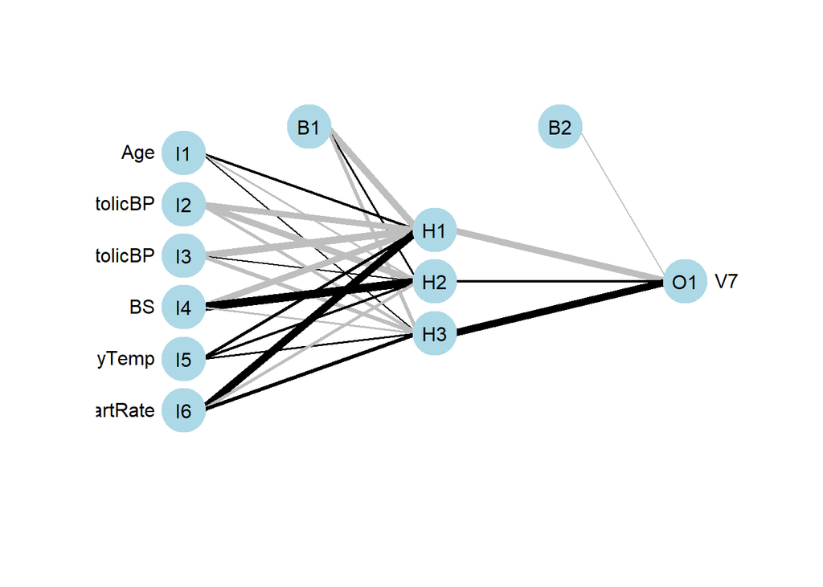

```r
#install.packages("NeuralNetTools")

library(NeuralNetTools)

NeuralNetTools::plotnet(mod)
```

```r
pred_red <- predict(mod, newdata = salud[-t.id.red,], type = "class")

#creamos una matriz de confusion

table(salud[-t.id.red,]$V7, pred_red, dnn = c("Actual","Predichos"))
```

```
##       Predichos
## Actual   0   1
##      0  85  36
##      1  38 144
```

Creamos una curva ROC para ver que tan bien clasifica.

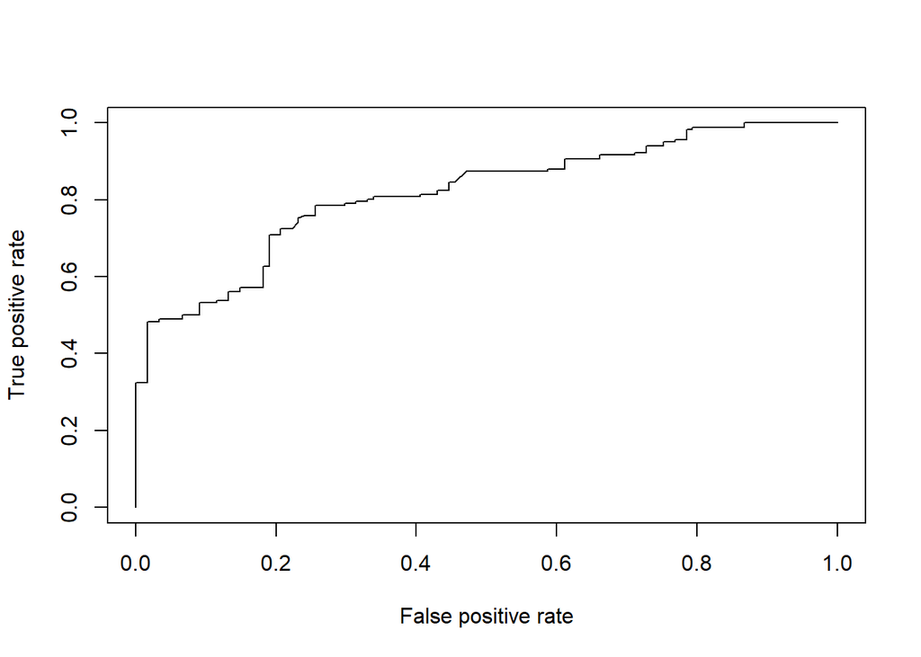

```r
library(ROCR)
pred2_red <- predict(mod, newdata = salud[-t.id.red,], type = "raw")
perf <- performance(prediction(pred2_red, salud[-t.id.red,"V7"]),
                    "tpr", "fpr")

plot(perf)
```

# Análisis Discriminante Lineal.

```r
library(caret)
#utilizamos los datos de salud igual que en el apartado anterior
salud_discriminante<-read.csv("C:\\Users\\Cristopher\\Desktop\\datos omicos git\\Machine learning R\\machine_learning_R\\Maternal_Health_Risk_Data_Set.csv", stringsAsFactors = TRUE)

#eliminamos la primera columna que es identificador y escalamos los datos

salud_discriminante = salud_discriminante[,-1]

salud_materna_scal<- scale(salud_discriminante[,-7])

salud_lineal_disc <- cbind(salud_materna_scal,salud_discriminante$RiskLevel)
#obtenemos los datos escalados y centrados mas la variable dependiente
salud_lineal_disc[1:5,1:7]
```

```
##               Age SystolicBP DiastolicBP         BS   BodyTemp  HeartRate
## [1,] -0.361559706  0.9129458   0.2548970  1.9049502 -0.4849762  1.4462425 1
## [2,]  0.380589164  1.4563085   0.9750574  1.2976993 -0.4849762 -0.5318251 1
## [3,] -0.064700158 -1.2605050  -0.4652634 -0.2204279  0.9734042  0.7044671 1
## [4,]  0.009514729  1.4563085   0.6149772 -0.5240533 -0.4849762 -0.5318251 1
## [5,]  0.380589164  0.3695831  -1.1854238 -0.7973162 -0.4849762  0.2099502 0
```

```r
#transformamos los data en dataframe
salud_lineal_disc = as.data.frame(salud_lineal_disc)
#transformamos la variable dependiente en factor

salud_lineal_disc$V7 = as.factor(salud_lineal_disc$V7)

#fijamos una semilla y creamos la particion de los datos

set.seed(2022)
t.id.disc <- createDataPartition(salud_lineal_disc$V7, p=0.7, list = F)

#seleccionamos los parametros de salida

library(MASS)
mod.disc <- lda(salud_lineal_disc[t.id.disc,1:6], salud_lineal_disc[t.id.disc,7])
```

```r
# Predecimos los valores, voy a utilizar el data frame original

salud_lineal_disc[t.id.disc, "Pred"] <- predict(mod.disc, salud_lineal_disc[t.id.disc, 1:6])$class

#creamos una matriz de confusion

table(salud_lineal_disc[t.id.disc, "V7"], salud_lineal_disc[t.id.disc, "Pred"], dnn = c("Actual","Predichos"))
```

```
##       Predichos
## Actual   0   1
##      0 190  95
##      1  98 328
```

```r
#Tenemos una variable de prediccion lleno de NAs, voy a cambiar los NAs con su prediccion.

salud_lineal_disc[-t.id.disc, "Pred"] <- predict(mod.disc, salud_lineal_disc[-t.id.disc, 1:6])$class
```

Revisamos si mejora en algo la prediccion con una tabla de confusion

```r
#podriamos hacer una table de doble entrada, una matriz de confusion.

table(salud_lineal_disc[-t.id.disc,"V7"], salud_lineal_disc[-t.id.disc, "Pred"], dnn = c("Actual","Predicho"))
```

```
##       Predicho
## Actual   0   1
##      0  88  33
##      1  49 133
```

# Regresión Logística.

```r
#Utilizamos los datos de las casas de boston

boston<-read.csv("C:\\Users\\Cristopher\\Desktop\\datos omicos git\\Machine learning R\\machine_learning_R\\boston.csv",stringsAsFactors = TRUE)

#escalamos las variables para que esten todas en la misma escala.

boston_scal <- scale(boston[,-7])

#juntamos los datos escalados con la variable dependiente
boston_datos<- cbind(boston_scal,boston$CLASS)

#transformar los datos en dataframe y la variable dependiente en factor

boston_datos = as.data.frame(boston_datos)

boston_datos$V7 = as.factor(boston_datos$V7)

#visualizamos los datos

head(boston_datos)
```

```
##          NOX       DIS        RAD        TAX    PTRATIO         B V7
## 1 -0.2103588 0.1858145 -1.0285168 -0.7068016 -1.3376716 0.4880252  1
## 2 -0.7843832 0.5879570 -0.9170353 -1.0174108 -0.2389867 0.4486835  1
## 3 -0.8758944 1.0900505 -0.8055537 -1.1324513  0.1565399 0.4660828  1
## 4 -0.8758944 1.0900505 -0.8055537 -1.1324513  0.1565399 0.4880252  1
## 5 -0.8758944 1.0900505 -0.8055537 -1.1324513  0.1565399 0.4611530  1
## 6 -0.3268275 1.0388370 -0.5825907 -0.6205213 -1.3816190 0.4880252  1
```

```r
set.seed(2020)

#creo el conjunto de entrenamiento:

t.id.logistica <- createDataPartition(boston_datos$V7, p=0.7, list = F)

#regresion logsitica

regresion_logistica<-glm(V7~.,data = boston_datos[t.id.logistica,],family = "binomial")

summary(regresion_logistica)
```

```
##
## Call:
## glm(formula = V7 ~ ., family = "binomial", data = boston_datos[t.id.logistica,
##     ])
##
## Deviance Residuals:
##      Min        1Q    Median        3Q       Max
## -2.24282  -0.37606   0.09777   0.44507   2.77977
##
## Coefficients:
##             Estimate Std. Error z value Pr(>|z|)
## (Intercept)  0.07219    0.23248   0.311  0.75616
## NOX         -2.52793    0.53088  -4.762 1.92e-06 ***
## DIS         -0.76422    0.32846  -2.327  0.01998 *
## RAD          1.56170    0.60120   2.598  0.00939 **
## TAX         -0.89520    0.61896  -1.446  0.14809
## PTRATIO     -1.68845    0.29094  -5.804 6.49e-09 ***
## B            1.01345    0.41979   2.414  0.01577 *
## ---
## Signif. codes:  0 '***' 0.001 '**' 0.01 '*' 0.05 '.' 0.1 ' ' 1
##
## (Dispersion parameter for binomial family taken to be 1)
##
##     Null deviance: 353.03  on 254  degrees of freedom
## Residual deviance: 161.44  on 248  degrees of freedom
## AIC: 175.44
##
## Number of Fisher Scoring iterations: 6
```

En este caso obtenemos que las variables estadisticamente significativas son NOX,DIS,RAD, PTRATIO y B.

```r
#Podemos calcular las probabilidades de exito para las validaciones como de los datos del modelo original.

boston_datos[-t.id.logistica, "PROB_SUCCESS"]<- predict(regresion_logistica, newdata = boston_datos[-t.id.logistica,], type = "response")

head(boston_datos)
```

```
##          NOX       DIS        RAD        TAX    PTRATIO         B V7
## 1 -0.2103588 0.1858145 -1.0285168 -0.7068016 -1.3376716 0.4880252  1
## 2 -0.7843832 0.5879570 -0.9170353 -1.0174108 -0.2389867 0.4486835  1
## 3 -0.8758944 1.0900505 -0.8055537 -1.1324513  0.1565399 0.4660828  1
## 4 -0.8758944 1.0900505 -0.8055537 -1.1324513  0.1565399 0.4880252  1
## 5 -0.8758944 1.0900505 -0.8055537 -1.1324513  0.1565399 0.4611530  1
## 6 -0.3268275 1.0388370 -0.5825907 -0.6205213 -1.3816190 0.4880252  1
##   PROB_SUCCESS
## 1           NA
## 2           NA
## 3           NA
## 4           NA
## 5    0.8041022
## 6           NA
```

```r
# Tenemos que elegir desde que probabilidad acepto que es un exito y desde cual es un fracaso, establecemos que en un 50% es un exito.

boston_datos[-t.id.logistica, "PRED_50"] <-ifelse(boston_datos[-t.id.logistica, "PROB_SUCCESS"]>=0.5,1,0)
```

Con una matriz de confusion veremos que tan bien predice

```r
boston_datos = as.data.frame(boston_datos)
table(boston_datos[-t.id.logistica,"V7"], boston_datos[-t.id.logistica, "PRED_50"], dnn=c("Actual","Predicho"))
```

```
##       Predicho
## Actual  0  1
##      0 42  9
##      1  5 52
```

Podemos observar que predice bastante bien en general.